# How to Analyze COVID-19 Data

In this project, we will walk you through a tutorial of the data science pipeline as we explore trends in COVID-19 data. My name is Rejas Raj.

COVID-19 has wreaked havoc on nearly all countries in the world. Although the death rate of the disease is relatively low, millions of lives have been lost, so it's essential that we understand trends in the spread of the disease so that we can figure out where to focus our efforts to mitigate it. There's an abundance of COVID-19 data available on the internet, and there's a variety of ways we can analyze the data to gain valuable insights from it. Much of the analyses we will do in this project will focus on COVID-19 cases, deaths, death rates, and how they vary among different regions, because knowing this could potentially give us insight into whether COVID-19 behaves differently in different climates, for example.

Let's start by collecting data.

### Data Collection

The first step of the data science pipeline is Data Collection, which is the process of retrieving data from the web and storing it into a data structure we can later manipulate and analyze. The COVID-19 dataset we will analyze in this project is the from the Center for Systems Science and Engineering (CSSE) at Johns Hopkins University. There are two tables we will retrieve: one consisting of data about COVID-19 cases, and the other consisting of data about COVID-19 deaths. Let's extract the data.

```python
# We need the Pandas library to read the data from the web into a DataFrame.
import pandas as pd
# The Pandas read_csv function extracts data from a CSV (comma-separated values) file and stores the result into a DataFrame.
# Url for COVID-19 cases data
url_cases = "https://raw.githubusercontent.com/CSSEGISandData/COVID-19/master/csse_covid_19_data/csse_covid_19_time_series/time_series_covid19_confirmed_global.csv"
# Read the COVID-19 cases table into a DataFrame.
df_cases = pd.read_csv(url_cases)
# Url for COVID-19 deaths data
url_deaths = "https://raw.githubusercontent.com/CSSEGISandData/COVID-19/master/csse_covid_19_data/csse_covid_19_time_series/time_series_covid19_deaths_global.csv"
# Read the COVID-19 deaths table into a DataFrame
df_deaths = pd.read_csv(url_deaths)
```

We now have our two tables stored into a Pandas DataFrame. A DataFrame is a 2-dimensional data structure that stores tabular data. Fortunately, the raw data came from CSV (comma-separated values) files, and the Pandas library has a function that allows us to easily store a CSV file into a DataFrame. If the raw data was not stored in a friendly format that we can easily store in a DataFrame, we would need some way to *parse* the data. Parsing is a complex step of the data collection process that involves matching the format of the raw data to rows in a DataFrame, which could be done with regular expressions, for example. Fortunately, we were able to obtain our DataFrames without the need for parsing. Let's display each of these DataFrames.

```python
# Display the cases DataFrame
df_cases
```

|  | Province/State | Country/Region | Lat | Long | 1/22/20 | 1/23/20 | 1/24/20 | 1/25/20 | 1/26/20 | 1/27/20 | ... | 5/6/22 | 5/7/22 | 5/8/22 | 5/9/22 | 5/10/22 | 5/11/22 | 5/12/22 | 5/13/22 | 5/14/22 | 5/15/22 |
| --- | --- | --- | --- | --- | --- | --- | --- | --- | --- | --- | --- | --- | --- | --- | --- | --- | --- | --- | --- | --- | --- |
| 0 | NaN | Afghanistan | 33.939110 | 67.709953 | 0 | 0 | 0 | 0 | 0 | 0 | ... | 178919 | 178922 | 178981 | 179010 | 179017 | 179131 | 179169 | 179203 | 179242 | 179267 |
| 1 | NaN | Albania | 41.153300 | 20.168300 | 0 | 0 | 0 | 0 | 0 | 0 | ... | 275310 | 275341 | 275366 | 275372 | 275416 | 275440 | 275485 | 275534 | 275574 | 275615 |
| 2 | NaN | Algeria | 28.033900 | 1.659600 | 0 | 0 | 0 | 0 | 0 | 0 | ... | 265791 | 265794 | 265798 | 265800 | 265804 | 265806 | 265808 | 265814 | 265816 | 265818 |
| 3 | NaN | Andorra | 42.506300 | 1.521800 | 0 | 0 | 0 | 0 | 0 | 0 | ... | 41717 | 41717 | 41717 | 41717 | 41717 | 41717 | 42156 | 42156 | 42156 | 42156 |
| 4 | NaN | Angola | -11.202700 | 17.873900 | 0 | 0 | 0 | 0 | 0 | 0 | ... | 99287 | 99287 | 99287 | 99287 | 99287 | 99287 | 99287 | 99287 | 99287 | 99287 |
| ... | ... | ... | ... | ... | ... | ... | ... | ... | ... | ... | ... | ... | ... | ... | ... | ... | ... | ... | ... | ... | ... |
| 280 | NaN | West Bank and Gaza | 31.952200 | 35.233200 | 0 | 0 | 0 | 0 | 0 | 0 | ... | 657060 | 657060 | 657060 | 657193 | 657193 | 657193 | 657193 | 657193 | 657193 | 657193 |
| 281 | NaN | Winter Olympics 2022 | 39.904200 | 116.407400 | 0 | 0 | 0 | 0 | 0 | 0 | ... | 535 | 535 | 535 | 535 | 535 | 535 | 535 | 535 | 535 | 535 |
| 282 | NaN | Yemen | 15.552727 | 48.516388 | 0 | 0 | 0 | 0 | 0 | 0 | ... | 11819 | 11819 | 11819 | 11819 | 11819 | 11819 | 11819 | 11819 | 11819 | 11819 |
| 283 | NaN | Zambia | -13.133897 | 27.849332 | 0 | 0 | 0 | 0 | 0 | 0 | ... | 319755 | 320099 | 320099 | 320157 | 320226 | 320303 | 320412 | 320481 | 320591 | 320627 |
| 284 | NaN | Zimbabwe | -19.015438 | 29.154857 | 0 | 0 | 0 | 0 | 0 | 0 | ... | 248214 | 248214 | 248352 | 248536 | 248642 | 248642 | 248943 | 249131 | 249206 | 249206 |

285 rows × 849 columns

```python
# Display the deaths DataFrame
df_deaths
```

|  | Province/State | Country/Region | Lat | Long | 1/22/20 | 1/23/20 | 1/24/20 | 1/25/20 | 1/26/20 | 1/27/20 | ... | 5/6/22 | 5/7/22 | 5/8/22 | 5/9/22 | 5/10/22 | 5/11/22 | 5/12/22 | 5/13/22 | 5/14/22 | 5/15/22 |
| --- | --- | --- | --- | --- | --- | --- | --- | --- | --- | --- | --- | --- | --- | --- | --- | --- | --- | --- | --- | --- | --- |
| 0 | NaN | Afghanistan | 33.939110 | 67.709953 | 0 | 0 | 0 | 0 | 0 | 0 | ... | 7684 | 7684 | 7684 | 7685 | 7685 | 7686 | 7686 | 7686 | 7687 | 7690 |
| 1 | NaN | Albania | 41.153300 | 20.168300 | 0 | 0 | 0 | 0 | 0 | 0 | ... | 3496 | 3496 | 3497 | 3497 | 3497 | 3497 | 3497 | 3497 | 3497 | 3497 |
| 2 | NaN | Algeria | 28.033900 | 1.659600 | 0 | 0 | 0 | 0 | 0 | 0 | ... | 6875 | 6875 | 6875 | 6875 | 6875 | 6875 | 6875 | 6875 | 6875 | 6875 |
| 3 | NaN | Andorra | 42.506300 | 1.521800 | 0 | 0 | 0 | 0 | 0 | 0 | ... | 153 | 153 | 153 | 153 | 153 | 153 | 153 | 153 | 153 | 153 |
| 4 | NaN | Angola | -11.202700 | 17.873900 | 0 | 0 | 0 | 0 | 0 | 0 | ... | 1900 | 1900 | 1900 | 1900 | 1900 | 1900 | 1900 | 1900 | 1900 | 1900 |
| ... | ... | ... | ... | ... | ... | ... | ... | ... | ... | ... | ... | ... | ... | ... | ... | ... | ... | ... | ... | ... | ... |
| 280 | NaN | West Bank and Gaza | 31.952200 | 35.233200 | 0 | 0 | 0 | 0 | 0 | 0 | ... | 5657 | 5657 | 5657 | 5657 | 5657 | 5657 | 5657 | 5657 | 5657 | 5657 |
| 281 | NaN | Winter Olympics 2022 | 39.904200 | 116.407400 | 0 | 0 | 0 | 0 | 0 | 0 | ... | 0 | 0 | 0 | 0 | 0 | 0 | 0 | 0 | 0 | 0 |
| 282 | NaN | Yemen | 15.552727 | 48.516388 | 0 | 0 | 0 | 0 | 0 | 0 | ... | 2149 | 2149 | 2149 | 2149 | 2149 | 2149 | 2149 | 2149 | 2149 | 2149 |
| 283 | NaN | Zambia | -13.133897 | 27.849332 | 0 | 0 | 0 | 0 | 0 | 0 | ... | 3976 | 3982 | 3982 | 3982 | 3983 | 3983 | 3983 | 3983 | 3983 | 3983 |
| 284 | NaN | Zimbabwe | -19.015438 | 29.154857 | 0 | 0 | 0 | 0 | 0 | 0 | ... | 5473 | 5473 | 5476 | 5479 | 5481 | 5481 | 5481 | 5482 | 5482 | 5482 |

285 rows × 849 columns

Above we can see the cases DataFrame and the deaths DataFrame, which shows that we have completed the Data Collection step. Upon completing this step, no more making requests to websites is necessary, and we now have data tables we can manipulate in a way that makes it possible to perform our analyses. The manipulation will happen in the Data Management step, which we will do now.

### Data Management

The Data Management step is where we organize the data we collected in a way that makes it ready to be analyzed. This often involves making our data *tidy*. Tidy data is a concept in data science that refers to a dataset that satisfies the following three properties:

1. Every column is a variable.
2. Every row is an observation.
3. Every cell is a single value.

For more information about tidy data, check out this article: https://cran.r-project.org/web/packages/tidyr/vignettes/tidy-data.html. Unfortunately, our DataFrames don't satisfy all three properties of tidy data. The second property is violated because we have multiple observations for each row (one for each date). To tidy our data, we need to convert the date columns into rows. Specifically, for the cases DataFrame, we will let the date column headers be values of a variable called Date, and we will name the case count variable Cases. We will do something similar for the deaths DataFrame. This process is called *melting*, and it's performed below. To learn more about melting, check the documentation for the Pandas melt function: https://pandas.pydata.org/docs/reference/api/pandas.melt.html.

```python
# First melt the cases DataFrame
# List of identifier columns
df_cases_id_vars = ["Province/State", "Country/Region", "Lat", "Long"]
# Name of variable who values are the names of all columns not in id_vars
df_cases_var_name = "Date"
# Name of observed variable
df_cases_value_name = "Cases"
# Melt the cases DataFrame
df_cases = df_cases.melt(
    id_vars = df_cases_id_vars,
    var_name = df_cases_var_name,
    value_name = df_cases_value_name
)
# Do the same for the deaths DataFrame
# List of identifier columns
df_deaths_id_vars = ["Province/State", "Country/Region", "Lat", "Long"]
# Name of variable who values are the names of all columns not in id_vars
df_deaths_var_name = "Date"
# Name of observed variable
df_deaths_value_name = "Deaths"
# Melt the deaths DataFrame
df_deaths = df_deaths.melt(
    id_vars = df_deaths_id_vars,
    var_name = df_deaths_var_name,
    value_name = df_deaths_value_name
)
```

Let's see what our DataFrames look like now.

```python
# Display cases DataFrame
df_cases
```

|  | Province/State | Country/Region | Lat | Long | Date | Cases |
| --- | --- | --- | --- | --- | --- | --- |
| 0 | NaN | Afghanistan | 33.939110 | 67.709953 | 1/22/20 | 0 |
| 1 | NaN | Albania | 41.153300 | 20.168300 | 1/22/20 | 0 |
| 2 | NaN | Algeria | 28.033900 | 1.659600 | 1/22/20 | 0 |
| 3 | NaN | Andorra | 42.506300 | 1.521800 | 1/22/20 | 0 |
| 4 | NaN | Angola | -11.202700 | 17.873900 | 1/22/20 | 0 |
| ... | ... | ... | ... | ... | ... | ... |
| 240820 | NaN | West Bank and Gaza | 31.952200 | 35.233200 | 5/15/22 | 657193 |
| 240821 | NaN | Winter Olympics 2022 | 39.904200 | 116.407400 | 5/15/22 | 535 |
| 240822 | NaN | Yemen | 15.552727 | 48.516388 | 5/15/22 | 11819 |
| 240823 | NaN | Zambia | -13.133897 | 27.849332 | 5/15/22 | 320627 |
| 240824 | NaN | Zimbabwe | -19.015438 | 29.154857 | 5/15/22 | 249206 |

240825 rows × 6 columns

```python
# Display deaths DataFrame
df_deaths
```

|  | Province/State | Country/Region | Lat | Long | Date | Deaths |
| --- | --- | --- | --- | --- | --- | --- |
| 0 | NaN | Afghanistan | 33.939110 | 67.709953 | 1/22/20 | 0 |
| 1 | NaN | Albania | 41.153300 | 20.168300 | 1/22/20 | 0 |
| 2 | NaN | Algeria | 28.033900 | 1.659600 | 1/22/20 | 0 |
| 3 | NaN | Andorra | 42.506300 | 1.521800 | 1/22/20 | 0 |
| 4 | NaN | Angola | -11.202700 | 17.873900 | 1/22/20 | 0 |
| ... | ... | ... | ... | ... | ... | ... |
| 240820 | NaN | West Bank and Gaza | 31.952200 | 35.233200 | 5/15/22 | 5657 |
| 240821 | NaN | Winter Olympics 2022 | 39.904200 | 116.407400 | 5/15/22 | 0 |
| 240822 | NaN | Yemen | 15.552727 | 48.516388 | 5/15/22 | 2149 |
| 240823 | NaN | Zambia | -13.133897 | 27.849332 | 5/15/22 | 3983 |
| 240824 | NaN | Zimbabwe | -19.015438 | 29.154857 | 5/15/22 | 5482 |

240825 rows × 6 columns

Perfect! Now each row contains a single observed value for a given region on a given date. We have tidied our data. Now, notice that our cases and deaths DataFrames look identical in structure. This suggests that merging the two tables would be appropriate. We will merge our cases and deaths DataFrames and store the result in a new DataFrame. The Pandas merge function makes this simple, and it's explained here: https://pandas.pydata.org/docs/reference/api/pandas.DataFrame.merge.html.

```python
# The pandas merge function takes two DataFrames and merges them (by default) on the intersection of their columns.
# Merge the cases and deaths DataFrames and store the result in a new DataFrame
df = pd.merge(df_cases, df_deaths)
# Display the new DataFrame
df
```

|  | Province/State | Country/Region | Lat | Long | Date | Cases | Deaths |
| --- | --- | --- | --- | --- | --- | --- | --- |
| 0 | NaN | Afghanistan | 33.939110 | 67.709953 | 1/22/20 | 0 | 0 |
| 1 | NaN | Albania | 41.153300 | 20.168300 | 1/22/20 | 0 | 0 |
| 2 | NaN | Algeria | 28.033900 | 1.659600 | 1/22/20 | 0 | 0 |
| 3 | NaN | Andorra | 42.506300 | 1.521800 | 1/22/20 | 0 | 0 |
| 4 | NaN | Angola | -11.202700 | 17.873900 | 1/22/20 | 0 | 0 |
| ... | ... | ... | ... | ... | ... | ... | ... |
| 240820 | NaN | West Bank and Gaza | 31.952200 | 35.233200 | 5/15/22 | 657193 | 5657 |
| 240821 | NaN | Winter Olympics 2022 | 39.904200 | 116.407400 | 5/15/22 | 535 | 0 |
| 240822 | NaN | Yemen | 15.552727 | 48.516388 | 5/15/22 | 11819 | 2149 |
| 240823 | NaN | Zambia | -13.133897 | 27.849332 | 5/15/22 | 320627 | 3983 |
| 240824 | NaN | Zimbabwe | -19.015438 | 29.154857 | 5/15/22 | 249206 | 5482 |

240825 rows × 7 columns

Voila! Now we have one table that stores both the cumulative case and death counts by each date for each region. We have tidied our data. There are some tradeoffs involved in deciding whether to tidy our data or leave it in the format it was in before. A benefit of the previous format is that the there is one row for each region, so we don't have duplicate rows with the same identifying information. However, we would have to use a nonstandard approach to analyze the change in cases and deaths over time since the dates are column headers, so tidying our data is the right choice. There is one more improvement we can make to our table. The values in the date column are strings, and it would be better if we converted them to Pandas DateTime objects. We will make this conversion now.

```python
# The Pandas to_datetime function converts string(s) to Pandas DateTime object(s)
# Convert the strings in the Date column to Pandas DateTime objects
df["Date"] = pd.to_datetime(df["Date"])
# Display the table
df
```

|  | Province/State | Country/Region | Lat | Long | Date | Cases | Deaths |
| --- | --- | --- | --- | --- | --- | --- | --- |
| 0 | NaN | Afghanistan | 33.939110 | 67.709953 | 2020-01-22 | 0 | 0 |
| 1 | NaN | Albania | 41.153300 | 20.168300 | 2020-01-22 | 0 | 0 |
| 2 | NaN | Algeria | 28.033900 | 1.659600 | 2020-01-22 | 0 | 0 |
| 3 | NaN | Andorra | 42.506300 | 1.521800 | 2020-01-22 | 0 | 0 |
| 4 | NaN | Angola | -11.202700 | 17.873900 | 2020-01-22 | 0 | 0 |
| ... | ... | ... | ... | ... | ... | ... | ... |
| 240820 | NaN | West Bank and Gaza | 31.952200 | 35.233200 | 2022-05-15 | 657193 | 5657 |
| 240821 | NaN | Winter Olympics 2022 | 39.904200 | 116.407400 | 2022-05-15 | 535 | 0 |
| 240822 | NaN | Yemen | 15.552727 | 48.516388 | 2022-05-15 | 11819 | 2149 |
| 240823 | NaN | Zambia | -13.133897 | 27.849332 | 2022-05-15 | 320627 | 3983 |
| 240824 | NaN | Zimbabwe | -19.015438 | 29.154857 | 2022-05-15 | 249206 | 5482 |

240825 rows × 7 columns

The date column now contains Pandas DateTimes, and our table is all polished now. We have completed the Data Management step of the data science pipeline. Upon completing this step, our data is now in a format that makes it easy to perform various types of analyses. We will do all these analyses now, in the Exploratory Data Analysis step.

### Exploratory Data Analysis

The Exploratory Data Analysis step of the data science pipeline is where we create plots and graphs so that we can visualize our data to discover patterns or trends in it. As we do this, we will ask questions we are curious about that we may be able to answer in more depth later, in the Hypothesis Testing step. We will first create a line plot showing the total COVID-19 cases over time.

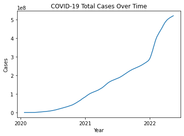

```python
# Pyplot is used for creating plots; dates is used for changing the tickmarks for our x-axis consisting of dates
from matplotlib import pyplot as plt, dates
# Create a figure and a set of subplots
fig, ax = plt.subplots()
# Set an appropriate title for the plot
plt.title("COVID-19 Total Cases Over Time")
# For each date, sum of up the COVID-19 cases across all regions, and plot it
# Group the DataFrame by date
group_by_date = df.groupby("Date")
# For each date, find the sum of the numeric columns for that date
group_by_date_sum = group_by_date.sum()
# Get the total cases by each date
total_cases_by_date = group_by_date_sum["Cases"]
# Plot the total cases by each date
plt.plot(df.groupby("Date").sum()["Cases"])
# Set an appropriate title for the x-axis
plt.xlabel("Year")
# Set an appropriate title for the y-axis
plt.ylabel("Cases")
# To avoid cluttered tick labels for the x-axis, just have one mark for each year
ax.xaxis.set_major_locator(dates.YearLocator())
# Display the plot
plt.show()
```

The graph above shows how the number of COVID-19 cases across the world increased over time. The growth rate seemed to increase until the beginning of 2021, remained steady until 2022, then jumped sharply in the beginning of 2022. This sharp jump is likely attributed to the rise of the Omicron variant early in 2022. Now let's look at COVID-19 deaths over time.

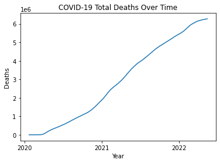

```python
# Create a figure and a set of subplots
fig, ax = plt.subplots()
# Set an appropriate title for the plot
plt.title("COVID-19 Total Deaths Over Time")
# For each date, sum of up the COVID-19 cases across all regions, and plot it
# Group the DataFrame by date
group_by_date = df.groupby("Date")
# For each date, find the sum of the numeric columns for that date
group_by_date_sum = group_by_date.sum()
# Get the total deaths by each date
total_deaths_by_date = group_by_date_sum["Deaths"]
# Plot the total deaths by each date
plt.plot(total_deaths_by_date)
# Set an appropriate title for the x-axis
plt.xlabel("Year")
# Set an appropriate title for the y-axis
plt.ylabel("Deaths")
# To avoid cluttered tick labels for the x-axis, just have one mark for each year
ax.xaxis.set_major_locator(dates.YearLocator())
# Display the plot
plt.show()
```

The graph above shows how the number of COVID-19 deaths across the world increased over time. The growth rate of COVID-19 deaths seemed to remain mostly steady throughout the years. Despite a sharp jump in the growth rate of COVID-19 cases during the rise of the Omicron variant, the rate of increase in the number of deaths stayed mostly constant, if not decreased slightly. This suggests that the death rate of the Omicron variant may be smaller than the death rate of other variants. Speaking of death rate, let's analyze how the overall COVID-19 death rate changed throughout the years.

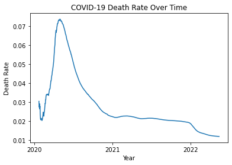

```python
# Create a figure and a set of subplots
fig, ax = plt.subplots()
# Set an appropriate title for the plot
plt.title("COVID-19 Death Rate Over Time")
# Calculate the death rate by each date
death_rate_by_date = total_deaths_by_date / total_cases_by_date
# Plot the death rate by each date
plt.plot(death_rate_by_date)
# Set an appropriate title for the x-axis
plt.xlabel("Year")
# Set an appropriate title for the y-axis
plt.ylabel("Death Rate")
# To avoid cluttered tick labels for the x-axis, just have one mark for each year
ax.xaxis.set_major_locator(dates.YearLocator())
# Display the plot
plt.show()
```

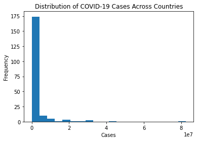

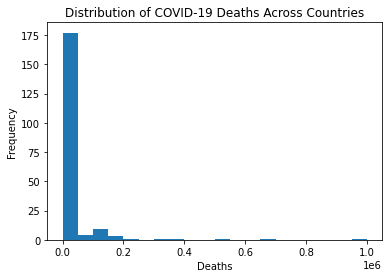

```python
# Create a figure and a set of subplots
fig, ax = plt.subplots()
# Set an appropriate title for the plot
plt.title("Distribution of COVID-19 Cases Across Countries")
# Get today's date as a DateTime
today = pd.to_datetime("5/15/22")
# Get the slice of the DateFrame consisting of only current data
df_today = df[df["Date"] == today]
# Group the DataFrame by country
group_by_country = df_today.groupby("Country/Region")
# For each country, find the sum of the numeric columns for that country
group_by_country_sum = group_by_country.sum()
# Get the total cases for each country
cases_for_each_country = group_by_country_sum["Cases"]
# Set a number of bins of the histogram
num_bins = 20
# Plot a histogram for the cases for each country
plt.hist(cases_for_each_country, num_bins)
# Set an appropriate title for the x-axis
plt.xlabel("Cases")
# Set an appropriate title for the y-axis
plt.ylabel("Frequency")
# Display the histogram
plt.show()
# Do the same for the deaths
# Create a figure and a set of subplots
fig, ax = plt.subplots()
# Set an appropriate title for the plot
plt.title("Distribution of COVID-19 Deaths Across Countries")
# Get the total deaths for each country
deaths_for_each_country = group_by_country_sum["Deaths"]
# Set a number of bins of the histogram
num_bins = 20
# Plot a histogram for the deaths for each country
plt.hist(deaths_for_each_country, num_bins)
# Set an appropriate title for the x-axis
plt.xlabel("Deaths")
# Set an appropriate title for the y-axis
plt.ylabel("Frequency")
# Display the histogram
plt.show()
```

The top graph shows the distribution of COVID-19 cases across countries, and the bottom graph shows the distribution of COVID-19 deaths across countries. Note that time isn't a variable here; the case and death counts the graphs refer to are the cumulative counts on the most recent date we have data for, May 15, 2022. Notice that both graphs are heavily right-skewed. Nearly all countries have less than 10 million cases and less than 100 thousand deaths, but a few have case and death counts much higher than these. Since our graphs are so skewed, it wouldn't make sense to make our x-scale have a constant magnitude. We should use a logarithmic scale instead. Below we will create the same histograms, but with a logarithmic scale for the x-axis. To help create our bins for the histogram, we will use the logspace function from the Numpy library. Here's some detail on how the logspace function works: https://numpy.org/doc/stable/reference/generated/numpy.logspace.html.

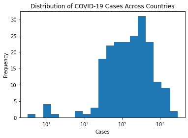

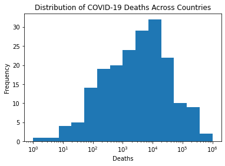

```python
# We need the numpy library to help create the logarithmic scale
import numpy as np
# Create a figure and a set of subplots
fig, ax = plt.subplots()
# Set an appropriate title for the plot
plt.title("Distribution of COVID-19 Cases Across Countries")
# Compute the minimum cases for a country
min_cases = cases_for_each_country.min()
# Compute the maximum cases for a country
max_cases = cases_for_each_country.max()
# Compute the base-10 logarithm of the minimum cases, or set it to zero if the minimum cases is zero
if min_cases > 0:
    log_min_cases = np.log10(min_cases)
else:
    log_min_cases = 0
# Compute the base-10 logarithm of the maximum cases
log_max_cases = np.log10(max_cases)
# Set a number of bins of the histogram
num_bins = 20
# Compute bins for the logarithmic histogram
bins = np.logspace(log_min_cases, log_max_cases, num_bins)
# Plot a histogram for the cases for each country using the logarithmic bins
plt.hist(cases_for_each_country, bins = bins)
# Set the x-scale of the histogram to be logarithmic
plt.xscale('log')
# Set an appropriate title for the x-axis
plt.xlabel("Cases")
# Set an appropriate title for the y-axis
plt.ylabel("Frequency")
# Display the histogram
plt.show()
# Do the same for the deaths
# Create a figure and a set of subplots
fig, ax = plt.subplots()
# Set an appropriate title for the plot
plt.title("Distribution of COVID-19 Deaths Across Countries")
# Compute the minimum deaths for a country
min_deaths = deaths_for_each_country.min()
# Compute the maximum deaths for a country
max_deaths = deaths_for_each_country.max()
# Compute the base-10 logarithm of the minimum deaths, or set it to zero if the minimum deaths is zero
if min_deaths > 0:
    log_min_deaths = np.log10(min_deaths)
else:
    log_min_deaths = 0
# Compute the base-10 logarithm of the maximum deaths
log_max_deaths = np.log10(max_deaths)
# Set a number of bins of the histogram
num_bins = 15
# Compute bins for the logarithmic histogram
bins = np.logspace(log_min_deaths, log_max_deaths, num_bins)
# Plot a histogram for the deaths for each country using the logarithmic bins
plt.hist(deaths_for_each_country, bins = bins)
# Set the x-scale of the histogram to be logarithmic
plt.xscale('log')
# Set an appropriate title for the x-axis
plt.xlabel("Deaths")
# Set an appropriate title for the y-axis
plt.ylabel("Frequency")
# Display the histogram
plt.show()
```

The histograms above are the same as the previous ones except the x-scale is now logarithmic. This means that we can now see how the *magnitude* of the number of COVID-19 cases varies between countries. Since the distribution of COVID-19 cases seems to be centered between 10^5 and 10^6, we can say that a country is expected to have hundreds of thousands of COVID-19 cases. Similarly, since the distribution of COVID-19 deaths seems to be centered between 10^3 and 10^4, we can say that a country is expected to have thousands of COVID-19 deaths. In terms of spread, both distributions seem slightly left-skewed. This means that while most countries have a relatively high magnitude of COVID-19 cases and deaths, some have a much smaller magnitude of cases and deaths.

There are some tradeoffs involved in choosing a logarithmic scale over a linear scale. A benefit of a linear scale is that it shows the distributions of cases and deaths more directly, while the logarithmic scale indirectly shows the distributions of cases and deaths by showing how they vary in magnitude across countries. However, since we could not learn much from the plots with a linear scale since nearly all countries fell into the first bin of the histograms, a logarithmic scale is the better alternative.

We've done a lot of analysis of COVID-19 cases and deaths, but let's take a look back at the death rate. We analyzed the overall death rate over time, but let's take this further. What if we wanted to know whether the COVID-19 death rate is different in tropical climates than in non-tropical climates? Let's split the countries into two categories: countries in the tropics and countries outside the tropics. We'll produce a line plot showing how the death rate in tropical countries changed over time and how the death rate in non-tropical countries changed over time. The tropics are defined as areas on earth within 23.43638 degrees north or south of the equator. In other words, the tropics consist of regions between -23.43638 degrees longitude and 23.43638 degrees longitude. Fortunately, our DataFrame provides latitude and longitude information for each region, so we can filter out tropical regions and non-tropical regions using conditional statements involving the longitude information. This is done below.

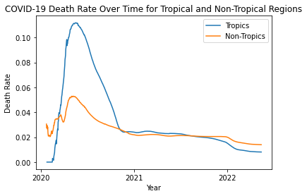

```python
# Create a figure and a set of subplots
fig, ax = plt.subplots()
# Set an appropriate title for the plot
plt.title("COVID-19 Death Rate Over Time for Tropical and Non-Tropical Regions")
# Get the slice of the DataFrame consisting of tropical regions
tropics = df[(df['Long'] >= -23.43638) & (df['Long'] <= 23.43638)]
# Get the slice of the DataFrame consisting of non-tropical regions
non_tropics = df[(df['Long'] < -23.43638) | (df['Long'] > 23.43638)]
# Group the tropics slice by date
tropics_group_by_date = tropics.groupby("Date")
# For each date, find the sum of the numeric columns for that date
tropics_group_by_date_sum = tropics_group_by_date.sum()
# Get the total cases by each date for the tropics slice
tropics_total_cases_by_date = tropics_group_by_date_sum["Cases"]
# Get the total deaths by each date for the tropics slice
tropics_total_deaths_by_date = tropics_group_by_date_sum["Deaths"]
# Group the non-tropics slice by date
non_tropics_group_by_date = non_tropics.groupby("Date")
# For each date, find the sum of the numeric columns for that date
non_tropics_group_by_date_sum = non_tropics_group_by_date.sum()
# Get the total cases by each date for the non-tropics slice
non_tropics_total_cases_by_date = non_tropics_group_by_date_sum["Cases"]
# Get the total deaths by each date for the non-tropics slice
non_tropics_total_deaths_by_date = non_tropics_group_by_date_sum["Deaths"]
# Plot the death rate by each date for the tropics
plt.plot(tropics_total_deaths_by_date / tropics_total_cases_by_date, label = "Tropics")
# Plot the death rate by each date for the non-tropics
plt.plot(non_tropics_total_deaths_by_date / non_tropics_total_cases_by_date, label = "Non-Tropics")
# Set an appropriate title for the x-axis
plt.xlabel("Year")
# Set an appropriate title for the y-axis
plt.ylabel("Death Rate")
# To avoid cluttered tick labels for the x-axis, just have one mark for each year
ax.xaxis.set_major_locator(dates.YearLocator())
# Add a legend to the plot
ax.legend()
# Display the plot
plt.show()
```

The graph above depicts the death rate over time for tropical and non-tropical regions. We can see that the death rate peaked much higher in the tropics than in the non-tropics, but this is likely because COVID-19 was present in just a few countries in its early stages, so those countries may have skewed the results. Besides the higher peak in the tropics, the death rate mostly seemed to follow a similar trend over time in the tropics and non-tropics. However, the current death rate in the non-tropics seems to be noticeably higher than the current death rate in the tropics. This makes us wonder whether there's a significant difference in the current death rate between tropical and non-tropical regions.

As you can see, we've learned a variety of information by looking at all the plots in our analysis. We've taken note of various trends and patterns in the data. This concludes the Exploratory Data Analysis step. However, notice that we left a question to answer: *is there a significant difference in the current death rate between tropical and non-tropical regions?* We will try to answer it now, in the Hypothesis Testing step.

### Hypothesis Testing

Let's come up with a way to test whether there is a significant difference in the current death rate between tropical and non-tropical regions. If we treat the death rates for the tropical regions and the death rates for the non-tropical regions as two independent samples, we can perform a two-sample t-test comparing the mean death rate between tropical and non-tropical regions. Let's do that below.

```python
# We will need the scipy.stats library to perform a two-sample t-test
from scipy.stats import ttest_ind
# Add a column for death rate, estimated as deaths divided by cases
df["Death Rate"] = df["Deaths"] / df["Cases"]
# Get the slice of the DataFrame consisting of current data for tropical regions where the number of cases is nonzero (to avoid dividing by zero)
tropics = df[(df["Date"] == today) & (df["Cases"] != 0) & (df['Long'] >= -23.43638) & (df['Long'] <= 23.43638)]
# Get the slice of the DataFrame consisting of current data for non-tropical regions where the number of cases is nonzero (to avoid dividing by zero)
non_tropics = df[(df["Date"] == today) & (df["Cases"] != 0) & ((df['Long'] < -23.43638) | (df['Long'] > 23.43638))]
# Run a two-sample t-test comparing the mean death rate in the tropics to the mean death rate in the non-tropics
result = ttest_ind(tropics['Death Rate'], non_tropics['Death Rate'])
# Get the test-statistic of the two-sample t-test
test_statistic = result.statistic
# Get the p-value of the two-sample t-test
p_value = result.pvalue
# Print the test-statistic
print("Test-statistic:", test_statistic)
# Print the p-value
print("p-value:", p_value)
```

```
Test-statistic: -0.5905285496444193
p-value: 0.5553143773769839
```

Above we have run a two-sample t-test to compare the mean death rate in tropical regions to the mean death rate in non-tropical regions. We will assume the death rates in tropical regions (as well as the death rates in non-tropical regions) follow a normal distribution. Our null hypothesis is that the mean COVID-19 death rate in tropical regions is the same as the mean COVID-19 death rate in non-tropical regions, and our alternative hypothesis is that the mean COVID-19 death rate in tropical regions is different from the mean COVID-19 death rate in non-tropical regions. We will test the null hypothesis at significance level 0.05. The test-statistic of the two-sample t-test, computed above, is -0.591, and its corresponding p-value is 0.555. Since p > 0.05, we fail to reject the null hypothesis. There's not enough evidence to conclude that the mean COVID-19 death rate differs between tropical regions and non-tropical regions.

Note that in choosing our hypothesis testing procedure, there are other alternatives we could have considered. For example, instead of comparing the mean of the death rates in tropical regions to the mean of the death rates in non-tropical regions, we could have compared the overall death rate in tropical regions with the overall death rate in non-tropical regions, where the overall death rate is total deaths divided by total cases. A benefit of this approach is that it more directly captures the death rates for these two different categories of regions, but it allows regions with higher cases and deaths to have more influence on the overall death rate than other regions. Our approach, on the other hand, ensures that each region has equal representation in the death rate, so our approach was chosen over the other approach.

Since we have tested our hypothesis, we have now completed the Hypothesis Testing step. Note that it isn't necessary to get a statistically significant result during hypothesis testing. All that matters is that we know what the results of the hypothesis testing step mean in the context of our data. Upon completing the Hypothesis Testing step, we have tried our best to answer any questions brought up by the Exploratory Data Analysis step, so now we are ready to communicate all the insights we learned. This will be done in the next step, Communication of Insights Attained.

### Communication of Insights Attained

The Communication of Insights Attained step is where we summarize all the information that we learned throughout the Exploratory Data Analysis and Hypothesis Testing steps and explain its implications.

We first noticed that the rise in COVID-19 cases over time was mostly steady until the beginning of 2022 when the cases skyrocketed. This underlines how transmissible the Omicron variant is, especially when it took over at the beginning of 2022.

We then noticed that although cases increased dramatically at the beginning of 2022, deaths did not, and the overall death rate has continued to decrease, especially after Omicron began. This suggests that maybe the Omicron variant has a lower death rate than other COVID-19 variants.

We then analyzed the distribution of COVID-19 cases across countries. We noticed that the COVID-19 cases and deaths differed in not just number but by orders of magnitude between different countries. This highlights how COVID-19 can spread exponentially, as the number of cases in a country could increase by orders of magnitude depending on how dense the country is and how effective its COVID-19 mitigation policies are.

Finally, we compared regions in the tropics with regions in the non-tropics. We saw that the death rate of COVID-19 seemed to follow a similar pattern over time between these two types of regions. Then, we conducted a two-sample t-test to see if there's a significant difference between the mean current death rate of tropical regions and the mean current death rate of non-tropical regions. We could not find enough evidence that there's a significant difference. However, this doesn't mean that COVID-19 behaves the same way regardless of climate. If we had other variables in our dataset that may relate to climate, one could take this project further and find other ways to test whether COVID-19 behaves differently in different climates.

Thank you for reading.